# How basic Is Our Spotifies

We’re gonna try to use spotify data to see how basic my music choices are

With the Spotify API we can pull my top Artists, and some data assciated with each of them

```r
#gonna import all just so we have them later
Sartists <- get_my_top_artists_or_tracks(50, type = "artists", time_range = "short_term")  %>%
     mutate(range = "short") %>%
     mutate(rangenum = 1) %>%
     mutate(rank = row_number())

Martists <- get_my_top_artists_or_tracks(50, type = "artists", time_range = "medium_term") %>%
     mutate(range = "mid") %>%
     mutate(rangenum = 2) %>%
     mutate(rank = row_number())

Lartists<- get_my_top_artists_or_tracks(50, type = "artists", time_range = "long_term") %>%
     mutate(range = "long") %>%
     mutate(rangenum = 3) %>%
     mutate(rank = row_number())

topartists <- list(Sartists, Martists, Lartists)

allTopArtists <- do.call('rbind', topartists)
```

I think a box and wiskers plot is gonna be the best option for visualing this

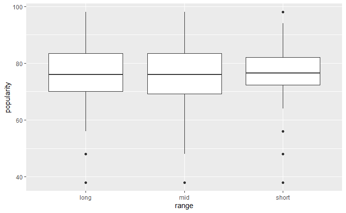

```r
#eve
allTopArtists %>%
  ggplot( aes(x=range, y=popularity)) +
    geom_boxplot() #+
```

```r
    #geom_jitter(color="black", size=0.4, alpha=0.9)
```

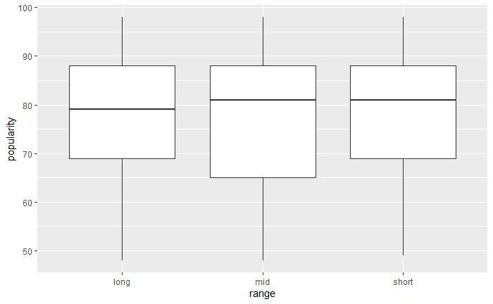

```r
load("results/lordTopArtists.Rdata")
tempTopArtists %>%
  ggplot( aes(x=range, y=popularity)) +
    geom_boxplot() #+
```

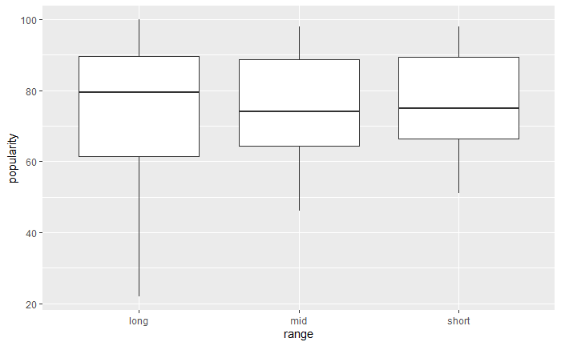

```r
load("results/desuTopArtists.Rdata")
tempTopArtists %>%
  ggplot( aes(x=range, y=popularity)) +
    geom_boxplot()
```

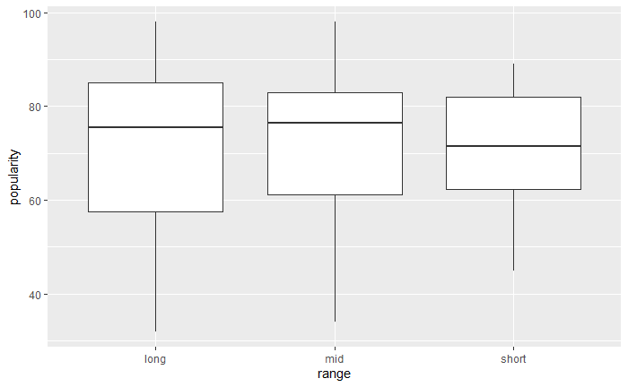

```r
load("results/SelahTopArtists.Rdata")
tempTopArtists %>%
  ggplot( aes(x=range, y=popularity)) +
    geom_boxplot()
```

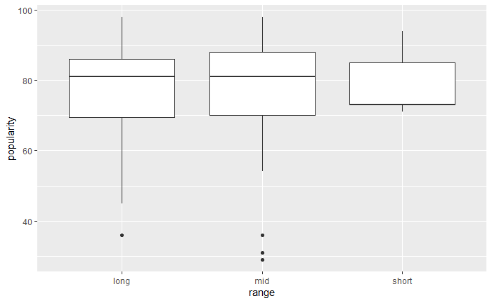

```r
load("results/cindyTopArtists.Rdata")
tempTopArtists %>%
  ggplot( aes(x=range, y=popularity)) +
    geom_boxplot()
```

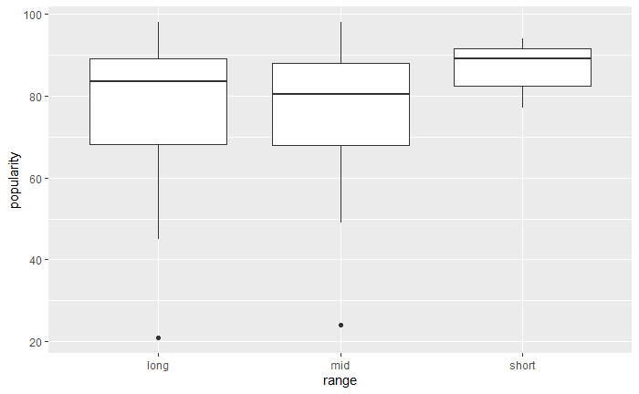

```r
load("results/claudiaTopArtists.Rdata")
tempTopArtists %>%
  ggplot( aes(x=range, y=popularity)) +
    geom_boxplot()
```

Let’s try violin

[figure not shown]

```r
tempTopArtists %>%
  ggplot( aes(x=range, y=popularity)) +
    geom_violin() #+
```

```r
    #geom_jitter(color="black", size=0.4, alpha=0.9)
```

What happens if we look at a diffrent var. So lets see if total.followers looks any different

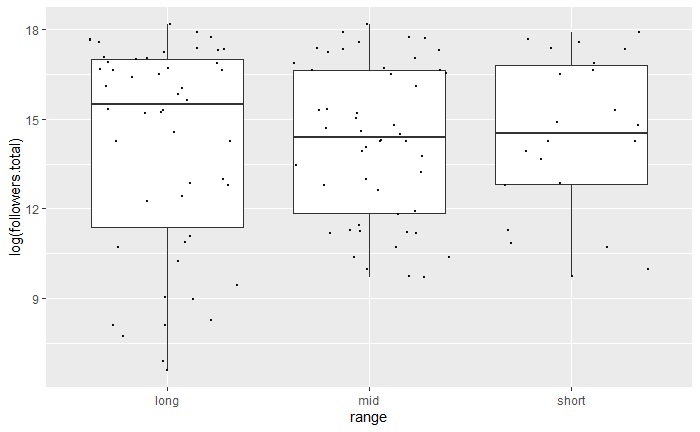

```r
load("results/desuTopArtists.Rdata")
tempTopArtists %>%
  ggplot( aes(x=range, y=log(followers.total))) +
    geom_boxplot() +
    geom_jitter(color="black", size=0.4, alpha=0.9)
```

```r
NA
NA
```

okay wanna test scaling the popularty score by how highly ranked an artist is

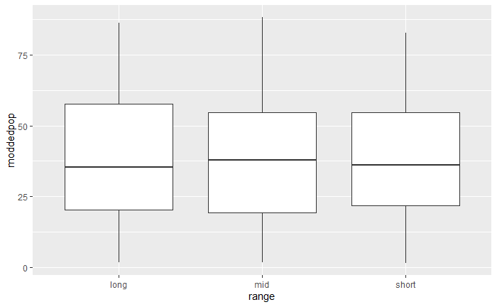

```r
#eve
allTopArtists %>%
  mutate(moddedpop = (popularity*(51-rank))/50) %>% #I think/100 does not work....
  ggplot( aes(x=range, y=moddedpop)) +
    geom_boxplot() #
```

```r
    #geom_jitter(color="black", size=0.4, alpha=0.9)
```

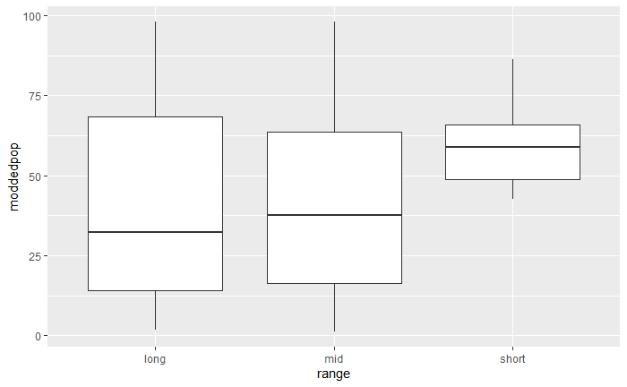

```r
load("results/desuTopArtists.Rdata")
tempTopArtists %>%
  mutate(moddedpop = (popularity*(51-rank))/50) %>% #I think/100 does not work....
  ggplot( aes(x=range, y=moddedpop)) +
    geom_boxplot() #
```

```r
    #geom_jitter(color="black", size=0.4, alpha=0.9)
```

```r
names = c("Eve", "desu", "cindy", "lord", "claudia", "Selah", "shubham")
NamesDataframes = list()
dir <- "results/"

for (i in 1:length(names)){
  filename <- paste(names[i], "TopArtists", sep="")

  #save as an Rdata object to keep the list cols
  load(file=paste(dir, filename, ".Rdata", sep = ""))

  NamesDataframes[[i]] <- tempTopArtists

}

allusersartists<- do.call("rbind", NamesDataframes)
```

[figure not shown]

```r
allusersartists %>%
  filter(range=="long") %>%
  #mutate(moddedpop = (popularity*(51-rank))/50) %>% #I think/100 does not work....
  ggplot( aes(x=userName, y=popularity)) +
    #geom_violin() +
    geom_boxplot() +
    geom_jitter(color="black", size=0.4, alpha=0.9)
```

```r
NA
NA
```

[figure not shown]

```r
allusersartists %>%
  filter(range=="long") %>%
  mutate(moddedpop = (popularity*(51-rank))/50) %>% #I think/100 does not work....
  ggplot( aes(x=userName, y=moddedpop)) +
    #geom_violin() +
    geom_boxplot() +
    geom_jitter(color="black", size=0.4, alpha=0.9)
```

```r
NA
```

Slightly diffrent, but not intresting enough for me. do some other plotting disrpubion chart but just bc im curous

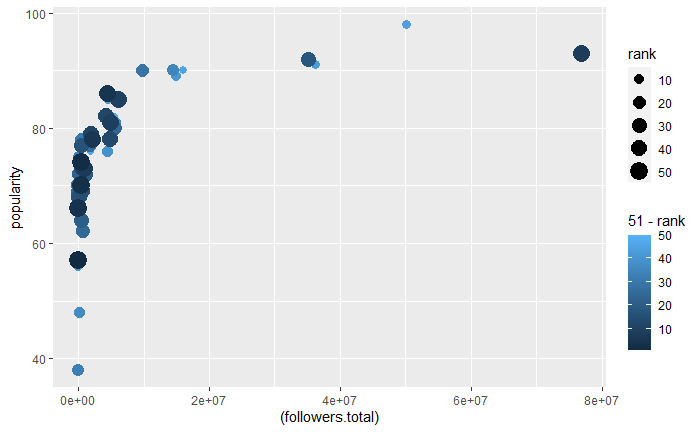

```r
#long artist only
p <- ggplot(Lartists, aes(x=(followers.total), y=popularity, color=51-rank, size=rank)) +
      geom_point()
p
```

Okay so I discovered that popularty is logmarithcally related to total followers. to compleat the test

[figure not shown]

```r
ggMarginal(p, type="histogram")
```

While understanding how spotify works is interesting, we only really care about one OR the other (or some new calculated metric ). Rank in comparisons to popularity seems more interesting no?

[figure not shown]

```r
ggplot(allTopArtists, aes(x=rank, y=popularity, color=range, size=51-rank)) +
      geom_point()
```

# Lets make an adgency matrix

Okay so we have a list of names, Its called names lol. Lets do a for loop

```r
matrix <- list()

for (i in 1:length(names)){
  row <- list()
  list1 <- allusersartists %>%
    filter(range == "long") %>%
    filter(userName == names[i])
  list1 <- as.list(list1)
  list1 <- list1[[5]]
  for(j in 1:length(names)){
    if (i != j){
      list2 <- allusersartists %>%
        filter(range == "long") %>%
        filter(userName == names[j])
      list2 <- as.list(list2)
      list2 <- list2[[5]]

      row[j] <- length(intersect(list1, list2))
    }
    else{
      row[j]=0
    }

  }
  #row[length(names) + 1 ] <- toString(list1)
  matrix[[i]] <- row
}
```

```r
u <- as.character(unlist(matrix, recursive=FALSE))
adjmatrix <- matrix(as.integer(u), nrow=length(names), byrow=TRUE)
#do <- data.frame(my.var=names(my.stuff), do, stringsAsFactors=FALSE)

rownames(adjmatrix) <- names

colnames(adjmatrix) <- names
#write.table(do, file="output/thresholdresults-twitter.csv", sep=",", col.names = NA, row.names = TRUE)
adjmatrix
```

```
        Eve desu cindy lord claudia Selah shubham
Eve       0    8     7    1       6     1       8
desu      8    0     9    3       8     7      10
cindy     7    9     0    7       4     3       5
lord      1    3     7    0       3     5       2
claudia   6    8     4    3       0     5       9
Selah     1    7     3    5       5     0       5
shubham   8   10     5    2       9     5       0
```

```r
#make this a graph and add some metadata

# Transform it in a graph format
network <- graph_from_adjacency_matrix(adjmatrix, weighted=TRUE, "undirected")

#add all the artist list to vertex data
for(vrtx in V(network)$name) {
  V(network)[vrtx]$artist_list <- toString(get_artist_list(vrtx))
}

#add overlap to edge data
for(i in 1:length(E(network))) {
  n1 = head_of(network, E(network)[i])$name
  n2 = tail_of(network, E(network)[i])$name
  E(network)[i]$intersect <- toString(get_intersection(n1, n2))
}
```

```r
#export grapg
# Transform it in a JSON format for d3.js
data_json <- d3_igraph(network)

# Save this file
write(data_json, "adjmatrix.json")
```

### helper functions

```r
get_artist_list <- function(n){
  list1 <- allusersartists %>%
    filter(range == "long") %>%
    filter(userName == n)
  list1 <- as.list(list1)
  list1 <- list1[[5]]

  return(list1)
}

get_intersection <- function(name1, name2) {

  list1 <- get_artist_list(name1)
  list2 <- get_artist_list(name2)

  return(intersect(list1, list2))

}
```

## you where wrong, adj matrx is the right thing. so this is a minor waste time but you learned shit and did end up using a function you made here to get it done!! #gigs

okay in part bc i think this is what i should have done in the firstplace , but also for shits and gigs lests make an edge list!

```r
edgelist <- list()

for (i in 1:length(names)){
  row <- list(names[i])
  list1 <- allusersartists %>%
    filter(range == "long") %>%
    filter(userName == names[i])
  list1 <- as.list(list1)
  list1 <- list1[[5]]
  for(j in 1:length(names)){
    if (i != j){
      list2 <- allusersartists %>%
        filter(range == "long") %>%
        filter(userName == names[j])
      list2 <- as.list(list2)
      list2 <- list2[[5]]
      if(length(intersect(list1, list2)) > 0){
         row[2] <- list(names[j])
         row[3] <- length(intersect(list1, list2))
         row[[4]] <- c(intersect(list1, list2))

      }

      edgelist[[length(edgelist) + 1]] <- row
    }


  }

}
```

Immediate issue with this edge list is that they are duplicated lmaoooo that might be okay but i have an idea to fix it (undertone: I hate thinkinking i know how to do things, always makes me wanna fix problems)

```r
edgelist <- list()

for (i in 1:length(names)){
  #row <- list(names[i])
  list1 <- allusersartists %>%
    filter(range == "long") %>%
    filter(userName == names[i])
  list1 <- as.list(list1)
  list1 <- list1[[5]]
  for(j in 1:length(names)){
    if (i != j){
      list2 <- allusersartists %>%
        filter(range == "long") %>%
        filter(userName == names[j])
      list2 <- as.list(list2)
      list2 <- list2[[5]]
      if(length(intersect(list1, list2)) > 0){
         row <- sort(c(names[i], names[j]))
         row <- as.list(row)
         #row[2] <- list(names[j])
         row[3] <- length(intersect(list1, list2))
         #row[[4]] <- c(intersect(list1, list2))

      }

      edgelist[[length(edgelist) + 1]] <- row
    }
  }

}
```

```r
get_artist_list <- function(n){
  list1 <- allusersartists %>%
    filter(range == "long") %>%
    filter(userName == n)
  list1 <- as.list(list1)
  list1 <- list1[[5]]

  return(list1)
}

get_intersection <- function(name1, name2) {
  # list1 <- allusersartists %>%
  #   filter(range == "long") %>%
  #   filter(userName == name1)
  # list1 <- as.list(list1)
  # list1 <- list1[[5]]

  list1 <- get_artist_list(name1)
  list2 <- get_artist_list(name2)
  # list2 <- allusersartists %>%
  #       filter(range == "long") %>%
  #       filter(userName == name2)
  # list2 <- as.list(list2)
  # list2 <- list2[[5]]
  #
  return(intersect(list1, list2))

}
```

Now we have a list of lists lets make it a dataframe

```r
u <- as.character(unlist(edgelist, recursive=FALSE))
edgelistdo <- matrix(u, nrow=length(edgelist), byrow=TRUE)
#do <- data.frame(my.var=names(my.stuff), do, stringsAsFactors=FALSE)
#rownames(do) <- names
colnames(edgelistdo) <- c("start", 'end', 'weight')

edgelistdo <- as.data.frame(edgelistdo) %>%
  mutate(weight = as.numeric(weight)) #%>%
  #mutate(list = unlist(get_intersection(start, end)))
```

```r
edgelistdo
```

| start | end | weight |
| --- | --- | --- |
| desu | Eve | 8 |
| cindy | Eve | 7 |
| Eve | lord | 1 |
| claudia | Eve | 6 |
| Eve | Selah | 1 |
| desu | Eve | 8 |
| cindy | desu | 9 |
| desu | lord | 3 |
| claudia | desu | 8 |
| desu | Selah | 7 |

[output cut: 20 more lines]

now we just gotta remove duplicates

```r
edgelistdo <- edgelistdo %>%
  distinct(start, end, weight, .keep_all = TRUE)

#write.table(edgelistdo, file="results/edgelist.csv", sep=",", col.names = TRUE, row.names = FALSE)
write_json(edgelistdo, path="results/edgelist.json",)
```